# Copy_of_MOM_Assignment_Tan_Xi_Zhi

Preparatory Codes

install relevant packages

```python
!pip install geopandas
!pip install pyshp
!pip install pygeos
!wget -nc https://raw.githubusercontent.com/brpy/colab-pdf/master/colab_pdf.py
```

[output not shown]

```python
from zipfile import ZipFile
import zipfile
from io import BytesIO
import pandas as pd
import numpy as np
import seaborn as sns
from google.colab import drive
import os
from google.colab import data_table
from sklearn.pipeline import Pipeline
from sklearn.preprocessing import scale
from sklearn.preprocessing import StandardScaler
from sklearn.model_selection import train_test_split
import matplotlib.pyplot as plt
from sklearn.cluster import KMeans
from sklearn.decomposition import PCA
from matplotlib import pyplot as plt
from sklearn.linear_model import Lasso
from sklearn.model_selection import GridSearchCV
import geopandas as gpd
import folium
import shapefile
import pyproj
import pygeos
from shapely.geometry import Point
from colab_pdf import colab_pdf
```

```python
def mount_drive(folder_path):
  drive.mount('/content/gdrive', force_remount = True)
  print(folder_path)
  os.chdir(folder_path)
  return os.listdir()
def get_zip(file_name):
  files=[file_name.open(file_names) for file_names in file_name.namelist()]
  return files.pop() if len(files) == 1 else files
def fix_data(data):
  if "CardNum " in data.columns:
    data.rename(columns={"CardNum ":"CardNum"},inplace=True)
  if "Depts" in data.columns:
    data.rename(columns={"Depts":"Dept"},inplace=True)
```

```python
#Import data
Access_data = zipfile.ZipFile('/content/gdrive/MyDrive/Application material/Applications/MOM/Project/Access_data.zip')
Access_data=get_zip(Access_data)
file_list=list()
var_list=list()
for file in Access_data:
   name=str(file)
   name=name.split("<zipfile.ZipExtFile name='")[1].split("' mode='r' compress_type=deflate>")[0]
   name=name.replace("-","_")
   if "csv" in name:
      names=name.replace('.csv',"")
      globals()[f"{names}"]=pd.read_csv(file)
      #if you want to add the file itself, add the word globals() in front of f"names"
      file_list.append([f"{names}"])
for file in file_list:
#Ensure Site column of each dataframe indicates the site of the data
  name=file[0]
  name=name.split("Site")[1].split("2")[0]
  globals()[f"{file[0]}"]['Site']=name
  var_list.append(globals()[f"{file[0]}"])
#append all dataframes
Sitedata=pd.concat(var_list,ignore_index=True)
#Card Number (If card no. starts with one or more "0", it will be removed, so we should reassign it)
Sitedata['CardNum'].apply(lambda x: x if str(x)=='nan' else str(x).zfill(8))
```

```
0        00001001
1        00001001
2        00001001
3        00001001
4        00001001
           ...
36686         NaN
36687         NaN
36688         NaN
36689         NaN
36690         NaN
Name: CardNum, Length: 36691, dtype: object
```

Should we drop null data? This sub-section will study the distribution and amount of null data. From the heatmap, it seems that there are a significant portion of data errors originating from a misnaming of columns in one or more of the datasets. Under normal circumstances, i would go back to my code to rectify it, however for chronological flow of you the reader, i will change it from here on. After rectifying misnamed columns in datasets, it seems the errors with CardNum has disappeared however there seems to be some missing data with Dept. My guess is that a bulk of the missing data originates from Visitor and Temporary passes as these Passes do not have a department tagged to them

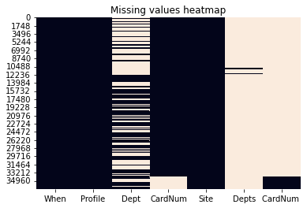

```python
#create heatmap to analyse missing data sources
sns.heatmap(Sitedata.isna(),cbar=False).set_title("Missing values heatmap")
```

```
When       0
Profile    0
Dept       0
CardNum    0
Site       0
dtype: int64
```

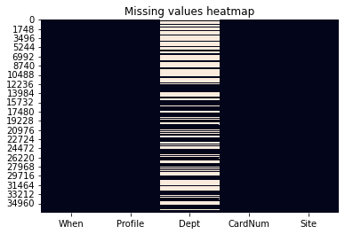

```python
#Rectify data error resulting from misnamed columns
for data in var_list:
  data=fix_data(data)
Sitedata=pd.concat(var_list,ignore_index=True)
Sitedata['CardNum']=Sitedata['CardNum'].apply(lambda x: x if str(x)=='nan' else str(x).zfill(8))
Sitedata['CardNum']=Sitedata['CardNum'].astype(str)
Sitedata['When'] =  pd.to_datetime(Sitedata['When'], format='%d/%m/%Y %H:%M')
#A second look: create heatmap to analyse missing data sources
sns.heatmap(Sitedata.isna(),cbar=False).set_title("Missing values heatmap")
#still missing data in dept,check number of missing data in non-staff cards
print(Sitedata.loc[Sitedata['Profile']==0].isna().sum())
```

```
['2' '1' '0']
```

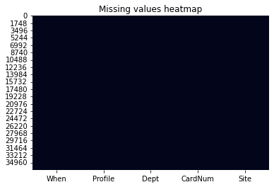

```python
#it seems that all Dept column missing data originates from Card numbers without staff Profile(AKA, profile!=0).
#thus, allocate all Dept rows with Tempt and Visitor status
Sitedata
#Check data errors in profile column
Sitedata['Profile'].loc[Sitedata['Profile']=='Visitor Pass']='2'
Sitedata['Profile'].loc[Sitedata['Profile']=='Temp Pass']='1'
Sitedata['Profile'].loc[Sitedata['Profile']=='Staff Pass']='0'
Sitedata['Profile'].loc[Sitedata['Profile']==2]='2'
Sitedata['Profile'].loc[Sitedata['Profile']==1]='1'
Sitedata['Profile'].loc[Sitedata['Profile']==0]='0'
print(Sitedata['Profile'].unique())
#Alter Dept data of Visitor and Temp
Sitedata['Dept'].loc[Sitedata['Profile']=='2']='Visitor'
Sitedata['Dept'].loc[Sitedata['Profile']=='1']='Temp'

#Check missing data heatmap again (no missing data observed)
sns.heatmap(Sitedata.isna(),cbar=False).set_title("Missing values heatmap")


#export data
Sitedata.to_csv('/content/gdrive/MyDrive/Application material/Applications/MOM/Project/Sitedata.csv',sep=',')
```

Section 2 Question 2.1

Data import and manipulation

```python
#Import data
Arrest_data = zipfile.ZipFile('/content/gdrive/MyDrive/Application material/Applications/MOM/Project/US_Arrest_Data.zip')
Arrest_data=get_zip(Arrest_data)
Arrest_file_list=list()
#Arrest_var_list=list()

#extract dataframes for each csv file in zip file
for file in Arrest_data:
   name=str(file)
   name=name.split("<zipfile.ZipExtFile name='")[1].split("' mode='r' compress_type=deflate>")[0]
   name=name.replace("-","_")
   if "csv" in name:
      names=name.replace('.csv',"")
      globals()[f"{names}"]=pd.read_csv(file)
      Arrest_file_list.append([f"{names}"])

###Data manipulation###
#label state column from USstatex77
USstatex77.rename(columns={'Unnamed: 0':'State'},inplace=True)
#Merge abbreviation with USstate77 for easier labelling
#USstatex77=pd.merge(USstatex77,USstateabb,left_index=True,right_index=True)
#USstatex77.drop(columns=['Unnamed: 0'],inplace=True)
#Merge all arrest data except murder to USstate
USArrestMerge=USArrest.drop(columns='Murder',axis=1)
USstatex77=pd.merge(USstatex77,USArrestMerge,left_on='State',right_on='Unnamed: 0')
USstatex77.drop(columns='Unnamed: 0',axis=1,inplace=True)
USstatex77.set_index('State',inplace=True)
```

Checking for missing data

```
Population    0
Income        0
Illiteracy    0
Life Exp      0
Murder        0
HS Grad       0
Frost         0
Area          0
Assault       0
UrbanPop      0
Rape          0
dtype: int64
```

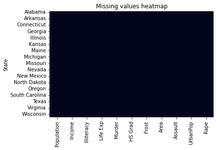

```python
print(USstatex77.isnull().sum())
sns.heatmap(USstatex77.isnull(),cbar=False).set_title("Missing values heatmap")
```

Visualizing correlation with scatterplot matrix and heatmap

```python
###standardize data###
scaler=StandardScaler()
USstate_std=scaler.fit_transform(USstatex77)
###transform numpy array back into dataframe
colname=list(USstatex77.columns)
USstate_std=pd.DataFrame(USstate_std,columns=colname)
USstate_std=pd.merge(USstate_std,USstateabb,left_index=True,right_index=True)
USstate_std.rename(columns={'x':'State'},inplace=True)
USstate_std.set_index('State',inplace=True)
USstate_std.drop('Unnamed: 0',axis=1,inplace=True)

###Scatterplot matrix
#plot=sns.pairplot(USstate_std,palette='Set1')
#plot.savefig("Section_II_Q1_1.png")
```

Sum of square distance of points to determine the number of clusters. It is determined that 5 would be an appropriate number of cluster.

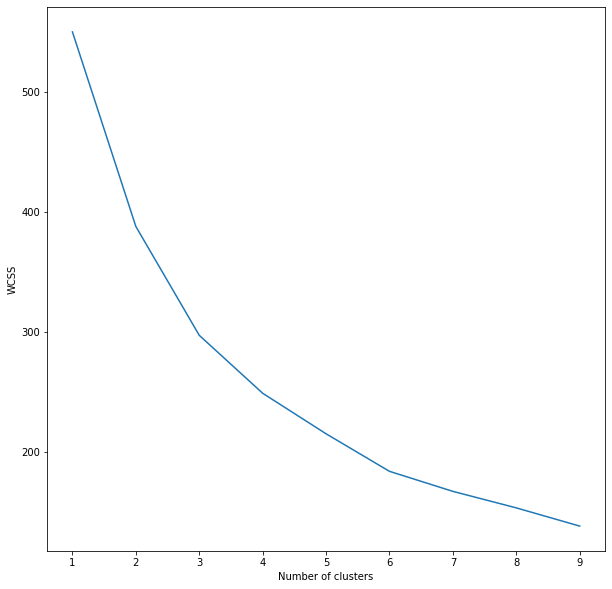

```python
wcss = []
for i in range(1,10):
   model = KMeans(n_clusters = i, init = "k-means++")
   model.fit(USstate_std)
   wcss.append(model.inertia_)
plt.figure(figsize=(10,10))
plt.plot(range(1,10), wcss)
plt.xlabel('Number of clusters')
plt.ylabel('WCSS')
plt.show()
#n=5
```

In this step, we will use PCA as a means of dimension reduction.While PCA is usually used in supervised learning models, dimension reduction helps to focus our clustering model on a smaller selection of variables,at the cost of some loss of explained variance. It is determined from the graph below that 2 should be sufficient to explain a majority (a little above 60%) of the variance within the data.

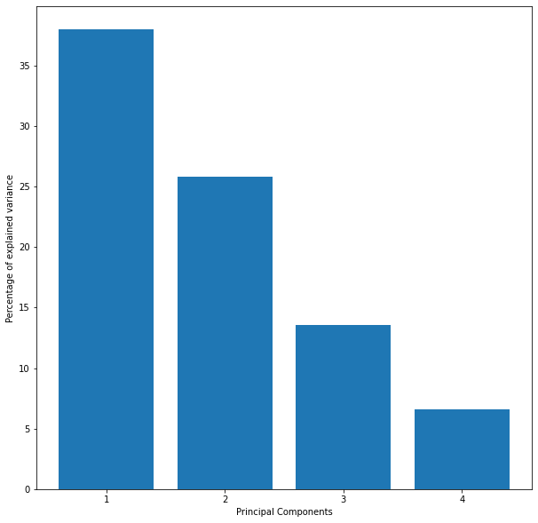

```python
pca = PCA(4)
USstate_2 = pca.fit_transform(USstate_std)
plt.figure(figsize=(10,10))
var = np.round(pca.explained_variance_ratio_*100, decimals = 1)
lbls = [str(x) for x in range(1,len(var)+1)]
plt.bar(x=range(1,len(var)+1), height = var, tick_label = lbls)
plt.xlabel('Principal Components')
plt.ylabel('Percentage of explained variance')
plt.show()
```

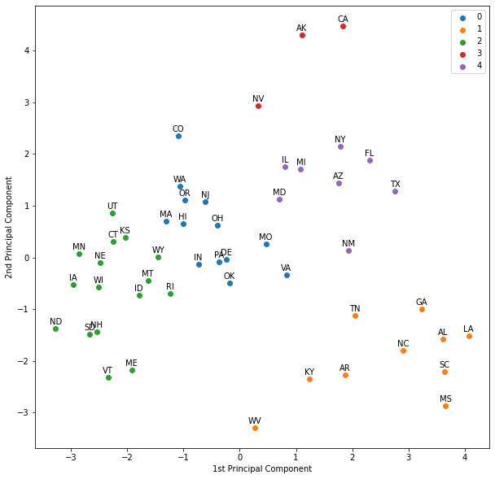

```python
pca = PCA(2)
USstate_main = pca.fit_transform(USstate_std)
model = KMeans(n_clusters = 5, init = "k-means++")
label = model.fit_predict(USstate_main)
#plot figure according to fitted clusters for each state
plt.figure(figsize=(10,10))
uniq = np.unique(label)
for i in uniq:
   ax=plt.scatter(USstate_main[label == i , 0] , USstate_main[label == i , 1] , label = i)
plt.xlabel('1st Principal Component')
plt.ylabel('2nd Principal Component')
plt.legend()

#transform x,y coordinate data to dataframe
USstate_coord=pd.DataFrame(USstate_main,columns=['X','Y'])
#Produce dataframe showing states cluster
USstate_cluster=pd.DataFrame(label,columns=['label'])
USstate_cluster=pd.merge(USstate_cluster,USstateabb,left_index=True,right_index=True)
USstate_cluster.drop(columns=['Unnamed: 0'],axis=1,inplace=True)
USstate_cluster.rename(columns={'x':'State'},inplace=True)
USstate_cluster=pd.merge(USstate_cluster,USstate_coord,left_index=True,right_index=True)

USstate_cluster.set_index('State',inplace=True)
USstate_cluster.sort_values(by='label')
#label points accordingly
for index,row in USstate_cluster.iterrows():
  plt.annotate(str(index),(row['X'],row['Y']),textcoords="offset points",xytext=(0,5),ha='center')

#show plot

fig1 = plt.gcf()

fig1.savefig('cluster.png', dpi=100)

plt.show()
```

Further study: Are there geographical relations for clustered regions?

```python
##part II : Get shapefile of regions
Regionshp = gpd.read_file('https://www.weather.gov/source/gis/Shapefiles/County/s_11au16.zip')
Regionshp.geometry=Regionshp.geometry.to_crs(epsg='4326')

Regionshp=pd.DataFrame(Regionshp)
Regionshp=pd.merge(Regionshp,USstate_cluster['label'],right_index=True,left_on='STATE',how='right')
Regionshp=gpd.GeoDataFrame(Regionshp,geometry='geometry',crs='EPSG:4326')
```

```python
US_coord = [38.807160,-101.682592]
m = folium.Map(location=US_coord, zoom_start=10)
folium.Choropleth(geo_data=Regionshp,name='geometry',data=Regionshp,columns=['STATE', 'label'], key_on='feature.properties.STATE', fill_color='Set1', fill_opacity=0.75, line_opacity=0.5, legend_name='Clustered Region').add_to(m)
display(m)
m.save("MOM.html")
```

[output not shown]

Part I:Data preparation and manipulation Note: As n is small (n=50) it was decided that splitting the data into train and test sets might result in inaccurate measurements of the predictability of the model as the test set would be too small.Thus, no train-test split was done.

```python
#Import data
Arrest_data = zipfile.ZipFile('/content/gdrive/MyDrive/Application material/Applications/MOM/Project/US_Arrest_Data.zip')
Arrest_data=get_zip(Arrest_data)
Arrest_file_list=list()
#Arrest_var_list=list()

#extract dataframes for each csv file in zip file
for file in Arrest_data:
   name=str(file)
   name=name.split("<zipfile.ZipExtFile name='")[1].split("' mode='r' compress_type=deflate>")[0]
   name=name.replace("-","_")
   if "csv" in name:
      names=name.replace('.csv',"")
      globals()[f"{names}"]=pd.read_csv(file)
      Arrest_file_list.append([f"{names}"])

##Create Dataframe of data
US_Q2_1=pd.DataFrame(USstatex77)
US_Q2_1.rename(columns={'Unnamed: 0':'State'},inplace=True)

###Process other dataframes

##US arrest data
#drop murder data
USArrest.drop(columns=['Murder'],inplace=True)
#merge data
US_Q2_1=pd.merge(US_Q2_1,USArrest,left_on='State',right_on='Unnamed: 0')
US_Q2_1.drop(columns=['Unnamed: 0'],inplace=True)

##USstateregion data
USstateregion=pd.get_dummies(USstateregion)
USstateregion.drop(columns=['Unnamed: 0'],inplace=True)
US_Q2_1=pd.merge(US_Q2_1,USstateregion,left_index=True,right_index=True)

##USstate area
USstatearea.rename(columns={'x':'Area'},inplace=True)
USstatearea.drop(columns=['Unnamed: 0'],inplace=True)
US_Q2_1=pd.merge(US_Q2_1,USstatearea,left_index=True,right_index=True)

###further manipulation of main data
US_Q2_1.set_index('State',inplace=True)
```

Part II: Hyperparameter tuning and Feature Selection

Since the number of observations (n) is only a little higher (n>p and not n>>p) than the number of parameters (p), this might result in an overfitted model.Hence we would need to shrink parameters which does not contribute to the predictive power of the model.

```python
###standardize data###
scaler=StandardScaler()
USstate_std=scaler.fit_transform(US_Q2_1)
###transform numpy array back into dataframe
colname=list(US_Q2_1.columns)
US_Q2_1=pd.DataFrame(USstate_std,columns=colname)
US_Q2_1=pd.merge(US_Q2_1,USstateabb,left_index=True,right_index=True)
US_Q2_1.rename(columns={'x':'State'},inplace=True)
US_Q2_1.set_index('State',inplace=True)
US_Q2_1.drop('Unnamed: 0',axis=1,inplace=True)


#separate dataset into independent (Y) and dependent(X) variables
X=US_Q2_1.drop(columns=['Assault'])
y=pd.DataFrame(US_Q2_1['Assault'])
l1_space = np.linspace(0, 1, 10)
param_grid = {'alpha': l1_space}
lasso=Lasso()
lasso_cv=GridSearchCV(lasso,param_grid,cv=5)
HT=lasso_cv.fit(X,y)

print("Best alpha value: {}".format(HT.best_params_['alpha']))
print("Best score: {}".format(HT.best_score_))
```

[output not shown]

```python
#Conduct Lasso Regression
lasso=Lasso(alpha=0.111111111)
# Fit the regressor to the data
lasso.fit(X,y)

# Compute and print the coefficients
lasso_coef = lasso.coef_
print(lasso_coef)

# Plot the coefficients
plt.plot(X.columns,lasso_coef)
plt.xticks(list(X.columns), rotation=75)
plt.axhline(y=0, color='r', linestyle='--')
plt.margins(0.02)
plt.show()

#create dataframe of important variables
columns=pd.DataFrame(X.columns)
lasso_coef=pd.DataFrame(lasso_coef)
Important_var=pd.merge(columns,lasso_coef,left_index=True,right_index=True)
Important_var.rename(columns={'0_x':'Variable','0_y':'Value'},inplace=True)
Important_var=Important_var.loc[Important_var['Value']!=0]
#get list of important variables to filter out of main list later
Imp_Var_list=list(Important_var['Variable'].unique())
print('The statistically significant predictor variables of interest are:',Imp_Var_list)

##From the graph below, it is shown that predictors crucial in explaining assault rates are :'Illiteracy', 'Life Exp', 'Murder', 'Frost', 'UrbanPop', 'Rape'
```

[output not shown]